# Bootstrapping (Notes)

STAT 155

Author

# Notes

You will not be able to render this document until you’ve filled in the code!

## Learning goals

Let $\beta$ be some *population parameter* and $\hat{\beta}$ be a *sample estimate* of $\beta$. In order to study the potential error in $\hat{\beta}$, you will…

- explore two approaches to approximating the sampling distribution of $\hat{\beta}$:
  - Central Limit Theorem (CLT)
  - bootstrapping
- identify the difference between *sampling* and *resampling*
- intuit how bootstrapping results can be used to make inferences about $\beta$

## Readings and videos

Please watch the following video **after** class:

- [bootstrapping](https://voicethread.com/myvoice/thread/15611638/97563140)

# Exercises

Rivers contain small concentrations of mercury which can accumulate in fish. Scientists studied this phenomenon among largemouth bass in the Wacamaw and Lumber rivers of North Carolina. One goal was to explore the relationship of a fish’s mercury concentration (Concen) with its size, specifically its Length:

E(Concen | Length) = $\beta_0$ + $\beta_1$ Length

To this end, they caught and evaluated 171 fish, recording the following:

| variable | meaning |
| --- | --- |
| River | Lumber or Wacamaw |
| Station | Station number where the fish was caught (0, 1, …, 15) |
| Length | Fish’s length (in centimeters) |
| Weight | Fish’s weight (in grams) |
| Concen | Fish’s mercury concentration (in parts per million; ppm) |

```r
# Load the data & packages
library(tidyverse)
library(readr)
fish <- read_csv("https://Mac-STAT.github.io/data/Mercury.csv")
```

Plot and model the relationship of mercury concentration with length:

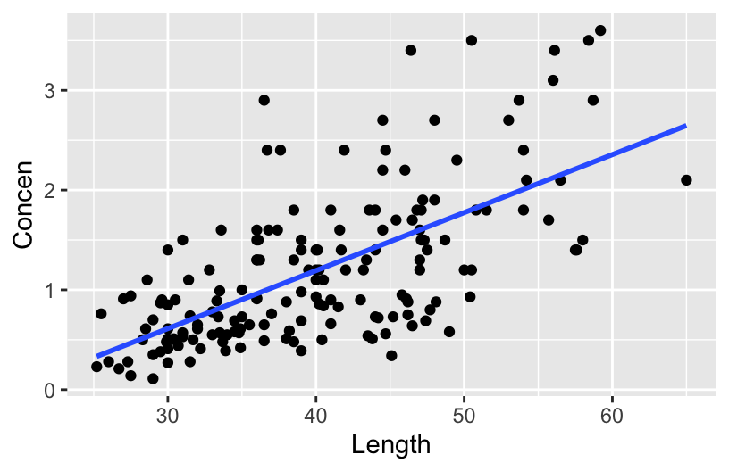

```r
fish %>%
  ggplot(aes(y = Concen, x = Length)) +
  geom_point() +
  geom_smooth(method = "lm", se = FALSE)
```

```r
fish_model <- lm(Concen ~ Length, data = fish)
coef(summary(fish_model))
##                Estimate  Std. Error   t value     Pr(>|t|)
## (Intercept) -1.13164542 0.213614796 -5.297598 3.617750e-07
## Length       0.05812749 0.005227593 11.119359 6.641225e-22
```

## Exercise 1: sample vs population

1. In the summary table, is the `Length` coefficient 0.058 the *population slope* $\beta_1$ or a *sample estimate* $\hat{\beta}_1$?
2. If it’s a sample estimate, how accurate do you think it is?

## Exercise 2: The rub

Since we don’t know $\beta_1$, we *can’t* know the exact error in $\hat{\beta}_1$! This is where **sampling distributions** come in. They describe how estimates $\hat{\beta}_1$ might vary from sample to sample, thus how far these estimates might fall from $\beta_1$:

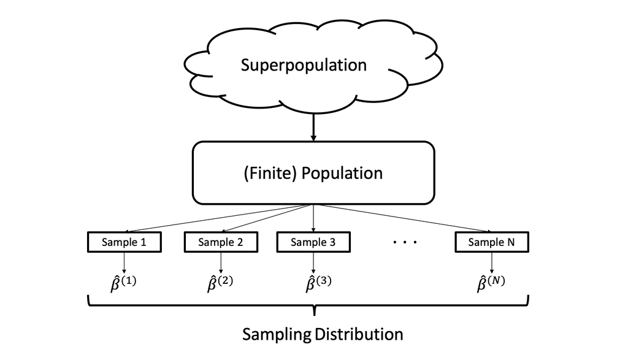

In past activities, we used simulations to approximate the sampling distribution. For example, we took and evaluated 500 different samples of 10 counties from the population of 3142 counties. Why can’t we do that here in our fish example?

## Exercise 3: CLT

In practice, we can’t *observe* the sampling distribution and its corresponding standard error. But we can *approximate* them. When our sample size n is “large enough”, we might approximate the sampling distribution using the CLT:

$$\hat{\beta}_1 \sim N(\beta_1, \text{standard error}^2)$$

The standard error in the CLT is approximated from our *sample* via some formula $c / \sqrt{n}$ where “c” is complicated. Obtain and interpret this standard error from the model summary table:

```r
coef(summary(fish_model))
##                Estimate  Std. Error   t value     Pr(>|t|)
## (Intercept) -1.13164542 0.213614796 -5.297598 3.617750e-07
## Length       0.05812749 0.005227593 11.119359 6.641225e-22
```

## REFLECT

Great! We can *approximate* the sampling distribution and standard error using the CLT. BUT:

- the *quality* of this approximation hinges upon the validity of the Central Limit *theorem* which hinges upon the validity of the *theoretical* model assumptions
- the CLT uses complicated formulas for the standard error estimates, thus can feel a little mysterious

Let’s explore how we can use **bootstrapping** to *complement* (not entirely replace) the CLT. The saying “*to pull oneself up by the bootstraps*” is often attributed to Rudolf Erich Raspe’s 1781 *The Surprising Adventures of Baron Munchausen* in which the character pulls himself out of a swamp by his hair (not bootstraps). In short, it means to get something from nothing, through your own effort:

[figure not shown]

In this spirit, statistical bootstrapping **doesn’t make any probability model assumptions**. It uses only the information from our one sample to approximate standard errors.

## Exercise 4: Challenge

Recall that we have a sample size of 171 fish:

```r
nrow(fish)
## [1] 171
```

We’ll obtain a **bootstrapping distribution** of $\hat{\beta}_1$ by taking many (500) different samples of 171 fish and exploring the degree to which $\hat{\beta}_1$ varies from sample to sample. Let’s try doing this as we did in past activities:

```r
# Build 500 models using samples of size 171
fish_models_bad_simulation <- mosaic::do(500)*(
  fish %>%
    sample_n(size = 171, replace = FALSE) %>%
    with(lm(Concen ~ Length))
)

head(fish_models_bad_simulation)
##   Intercept     Length     sigma r.squared        F numdf dendf .row .index
## 1 -1.131645 0.05812749 0.5805245 0.4224989 123.6401     1   169    1      1
## 2 -1.131645 0.05812749 0.5805245 0.4224989 123.6401     1   169    1      2
## 3 -1.131645 0.05812749 0.5805245 0.4224989 123.6401     1   169    1      3
## 4 -1.131645 0.05812749 0.5805245 0.4224989 123.6401     1   169    1      4
## 5 -1.131645 0.05812749 0.5805245 0.4224989 123.6401     1   169    1      5
## 6 -1.131645 0.05812749 0.5805245 0.4224989 123.6401     1   169    1      6
```

What’s funny about the results? Why do you think this happened? How might you adjust the code to “fix” things?

## Exercise 5: Resampling

In practice, we take *one sample* of size n from the population. To obtain a *bootstrapping distribution* of some sample estimate $\hat{\beta}$, we…

- take many **re**samples of size n **with replacement** from the sample
- calculate $\hat{\beta}$ using each resample

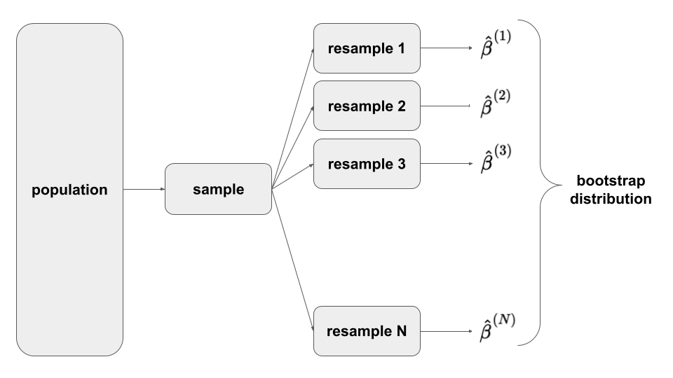

Let’s wrap our minds around the idea of *resampling* using a small example of 5 fish:

```r
# Define data
small_sample <- data.frame(
  id = 1:5,
  Length = c(44, 43, 54, 52, 40))

small_sample
##   id Length
## 1  1     44
## 2  2     43
## 3  3     54
## 4  4     52
## 5  5     40
```

This sample has a mean Length of 46.6 cm:

```r
small_sample %>%
  summarize(mean(Length))
##   mean(Length)
## 1         46.6
```

1. The chunk below samples 5 fish *without* replacement from our `small_sample` of 5 fish, and calculates their mean length. Run it several times. How do the sample and resulting mean change?

```r
sample_1 <- sample_n(small_sample, size = 5, replace = FALSE)
sample_1
##   id Length
## 1  5     40
## 2  2     43
## 3  4     52
## 4  3     54
## 5  1     44

sample_1 %>%
  summarize(mean(Length))
##   mean(Length)
## 1         46.6
```

2. Sampling our sample *without* replacement merely returns our original sample. Instead, *resample* 5 fish from our `small_sample` *with* replacement. Run it several times. What do you notice about the samples? About their mean lengths?

```r
sample_2 <- sample_n(small_sample, size = 5, replace = TRUE)
sample_2
##   id Length
## 1  5     40
## 2  5     40
## 3  2     43
## 4  1     44
## 5  1     44

sample_2 %>%
  summarize(mean(Length))
##   mean(Length)
## 1         42.2
```

3. *Resampling* our sample provides insight into the variability, hence potential error, in our sample estimates. (This works better when we have a sample bigger than 5!) As you observed in part b, each resample might include some fish from the original sample several times and others not at all. Why is this ok?